# White_Wine_Quality_analysis

Nilesh Kumar Srivastava

September 22, 2017

========================================================

INTRODUCTION : This tidy data set contains 4,898 white wines with 13 variables on quantifying the chemical properties of each wine. At least 3 wine experts rated the quality of each wine, providing a rating between 0 (very bad) and 10 (very excellent).

```
##   X fixed.acidity volatile.acidity citric.acid residual.sugar chlorides
## 1 1           7.0             0.27        0.36           20.7     0.045
## 2 2           6.3             0.30        0.34            1.6     0.049
## 3 3           8.1             0.28        0.40            6.9     0.050
## 4 4           7.2             0.23        0.32            8.5     0.058
## 5 5           7.2             0.23        0.32            8.5     0.058
## 6 6           8.1             0.28        0.40            6.9     0.050
##   free.sulfur.dioxide total.sulfur.dioxide density   pH sulphates alcohol
## 1                  45                  170  1.0010 3.00      0.45     8.8
## 2                  14                  132  0.9940 3.30      0.49     9.5
## 3                  30                   97  0.9951 3.26      0.44    10.1
## 4                  47                  186  0.9956 3.19      0.40     9.9
## 5                  47                  186  0.9956 3.19      0.40     9.9
## 6                  30                   97  0.9951 3.26      0.44    10.1
##   quality
## 1       6
## 2       6
## 3       6
## 4       6
## 5       6
## 6       6
```

# Removing unneccessary columns

```
##  [1] "fixed.acidity"        "volatile.acidity"     "citric.acid"
##  [4] "residual.sugar"       "chlorides"            "free.sulfur.dioxide"
##  [7] "total.sulfur.dioxide" "density"              "pH"
## [10] "sulphates"            "alcohol"              "quality"
```

Now we have only 12 variables in our dataset which will be used in our analysis. Before going to analysis part, let’s have a idea about all the variables present in our dataset.

1. fixed.acidity - The predominant fixed acids found in wines are tartaric, malic, citric, and succinic.These high-acid wines can be treated to reduce the acidity, either by neutralizing agents, or by malo-lactic fermentation.
2. volatile.acidity - Volatile acidity is mostly caused by bacteria in the wine creating acetic acid - the acid that gives vinegar its characteristic flavor and aroma.
3. citric.acid - Citric acid, minor in grapes but major in many other fruits, is often added to wines to increase acidity, complement a specific flavor or prevent ferric hazes.
4. residual.sugar - Residual Sugar (RS) This is the level of glucose and fructose (grape sugars) that are not converted into alcohol during fermentation.
5. chlorides - It determines the amont of salt present in wine.
6. free.sulfur.dioxide - For white wines, a level of 0.8 ppm molecular SO2 will slow down the growth of yeast and will prevent the growth of most other microbes. This level of sulfur dioxide will bind up most of the acetaldehyde in a wine and reduce any oxidation aroma considerably.
7. total.sulfur.dioxide - Bound sulfur dioxide is chemically bonded to other wine materials and this form plays a more or less passive role in winemaking. The sum of the free and bound sulfur dioxide is called total sulfur dioxide.
8. density - concentration of ethanol.
9. pH - Most wine pH’s fall around 3 or 4; about 3.0 to 3.4 is desirable for white wines.
10. sulphates - Sulfites are created naturally during the fermentation process. After a wine has fermented it usually contains somewhere between 2 and 10 parts per million (ppm).
11. alcohol - 9%-16% (most often 12.5%-14.5%)
12. quality - It depends on score between 0-10. and we are analysing quality of white wine in our analysis.

# Univariate Plots Section

```
##  fixed.acidity    volatile.acidity  citric.acid     residual.sugar
##  Min.   : 3.800   Min.   :0.0800   Min.   :0.0000   Min.   : 0.600
##  1st Qu.: 6.300   1st Qu.:0.2100   1st Qu.:0.2700   1st Qu.: 1.700
##  Median : 6.800   Median :0.2600   Median :0.3200   Median : 5.200
##  Mean   : 6.855   Mean   :0.2782   Mean   :0.3342   Mean   : 6.391
##  3rd Qu.: 7.300   3rd Qu.:0.3200   3rd Qu.:0.3900   3rd Qu.: 9.900
##  Max.   :14.200   Max.   :1.1000   Max.   :1.6600   Max.   :65.800
##    chlorides       free.sulfur.dioxide total.sulfur.dioxide
##  Min.   :0.00900   Min.   :  2.00      Min.   :  9.0
##  1st Qu.:0.03600   1st Qu.: 23.00      1st Qu.:108.0
##  Median :0.04300   Median : 34.00      Median :134.0
##  Mean   :0.04577   Mean   : 35.31      Mean   :138.4
##  3rd Qu.:0.05000   3rd Qu.: 46.00      3rd Qu.:167.0
##  Max.   :0.34600   Max.   :289.00      Max.   :440.0
##     density             pH          sulphates         alcohol
##  Min.   :0.9871   Min.   :2.720   Min.   :0.2200   Min.   : 8.00
##  1st Qu.:0.9917   1st Qu.:3.090   1st Qu.:0.4100   1st Qu.: 9.50
##  Median :0.9937   Median :3.180   Median :0.4700   Median :10.40
##  Mean   :0.9940   Mean   :3.188   Mean   :0.4898   Mean   :10.51
##  3rd Qu.:0.9961   3rd Qu.:3.280   3rd Qu.:0.5500   3rd Qu.:11.40
##  Max.   :1.0390   Max.   :3.820   Max.   :1.0800   Max.   :14.20
##     quality
##  Min.   :3.000
##  1st Qu.:5.000
##  Median :6.000
##  Mean   :5.878
##  3rd Qu.:6.000
##  Max.   :9.000
```

# Analysis of summary :

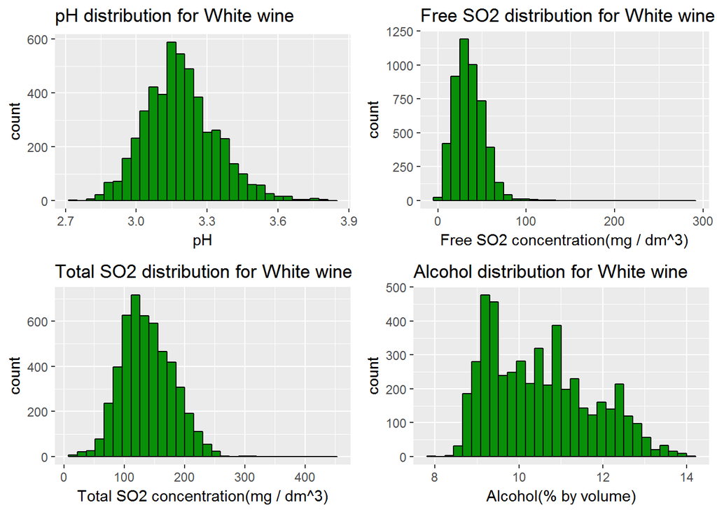

Alcohol distribution does show a bimodal plot and if we would increase the binwidth then this would be more clear. Rest plots show a normal distribution

# Univariate Analysis

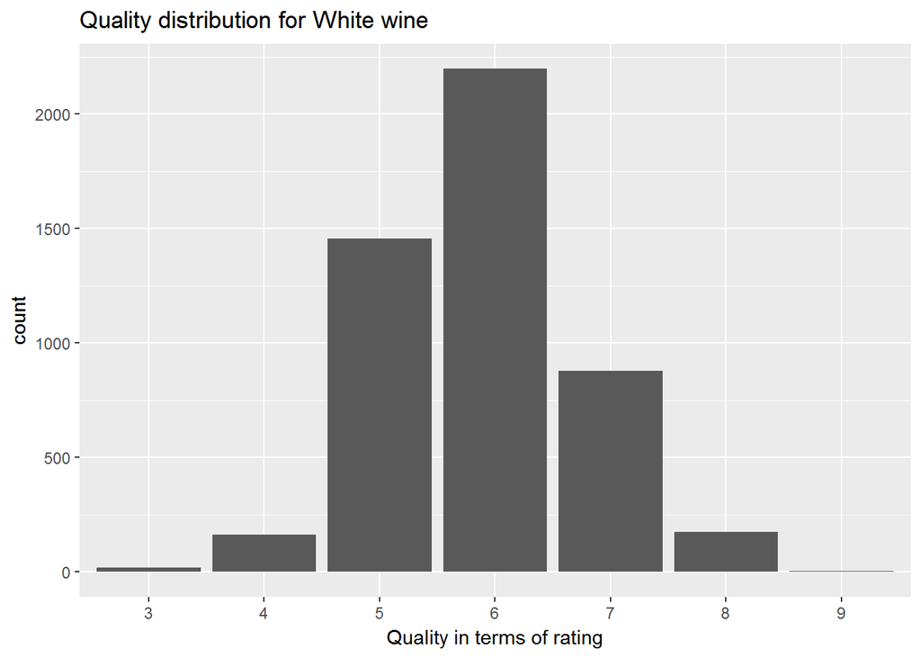

Here we can observe that most of sample is of 6 and more rating so our wine sample is preety nice.But there are few values at 3 & 4, which can be taken as non-desirable values as rating of 3-4 falls in a poor category.

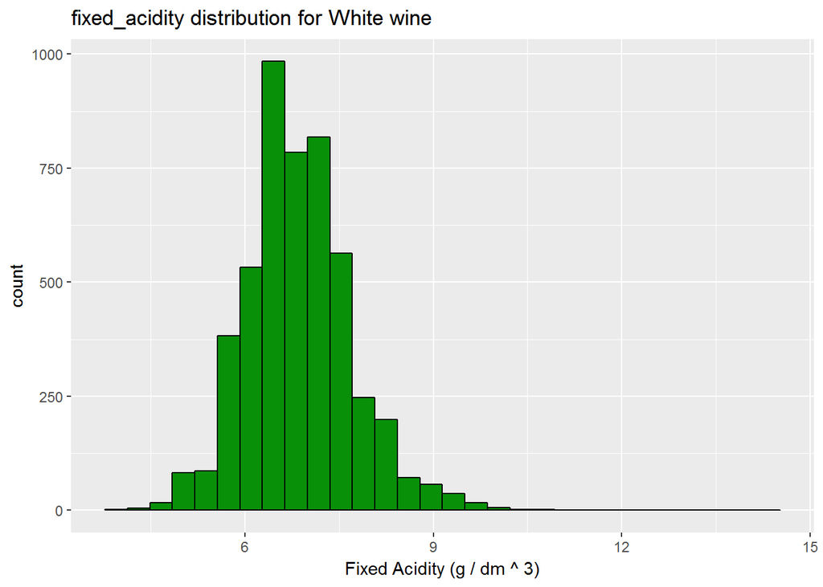

This plot shows a normal distribution and their are some outliers present in the plot and we can remove them by limitting the x-axis.

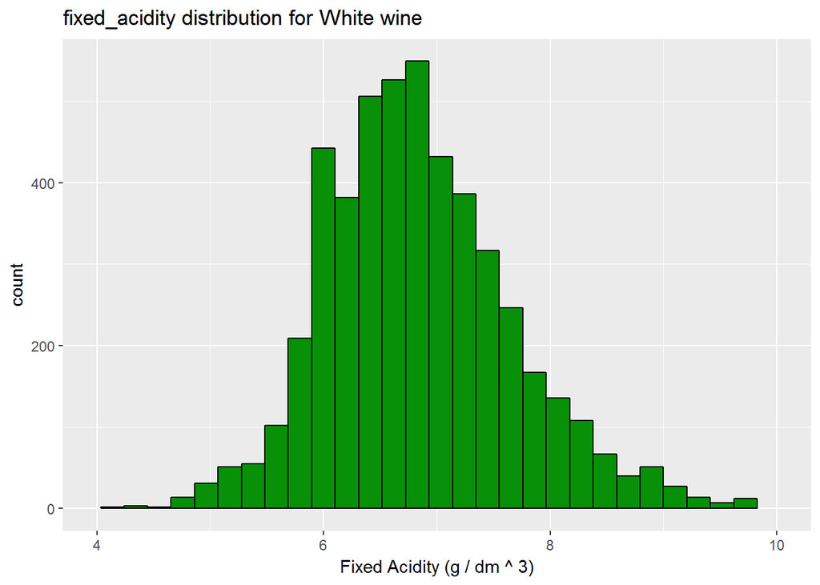

Now I have removed outliers in this plot by limiting the x-axis and this plot looks more normal now and by looking at plot only we can say that mean and median are close to each other.

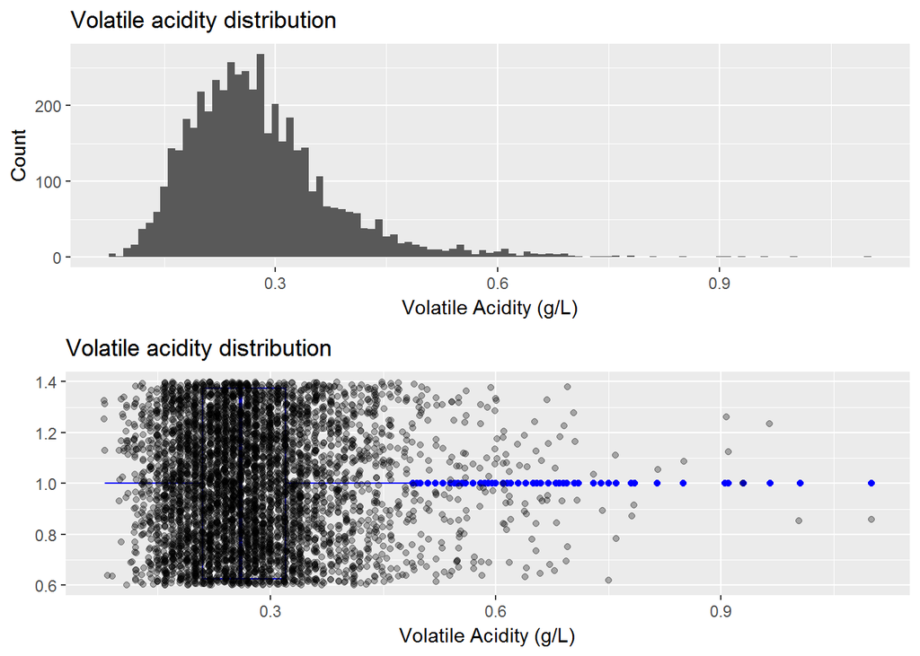

here we can see that volatile acidity is have a tail of outliers , which is better depicted from the box plot and the range for acidity is in admissible range which shows our sample is of good quality.

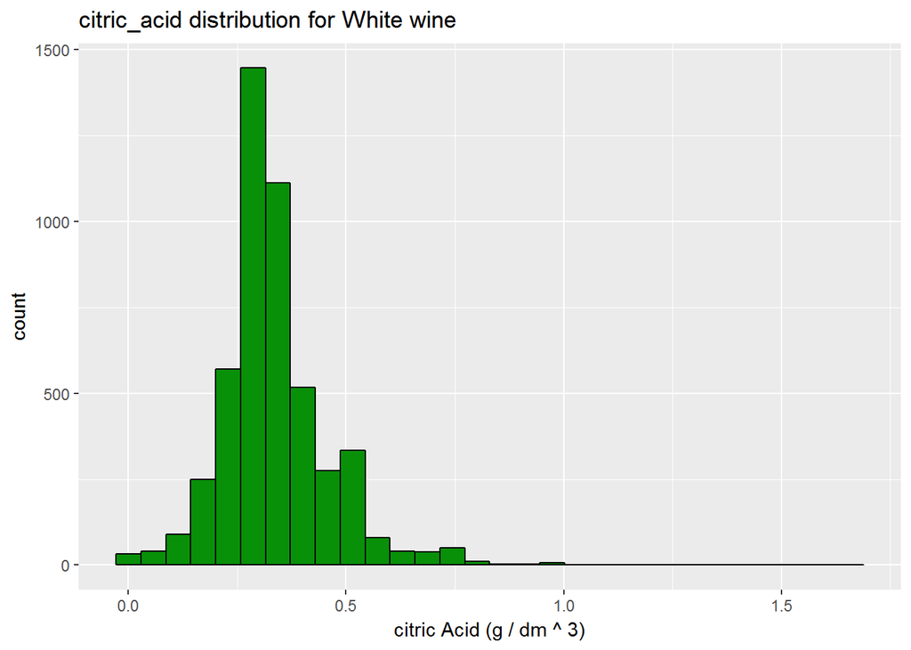

Citric acid plays a major role in a winemakers influence on acidity. Many winemakers use citric acid to acidify wines that are too basic and as a flavor additive. This process has is benefits and drawbacks. Adding citric acid will give the wine “freshness” otherwise not present and will effectively make a wine more acidic.

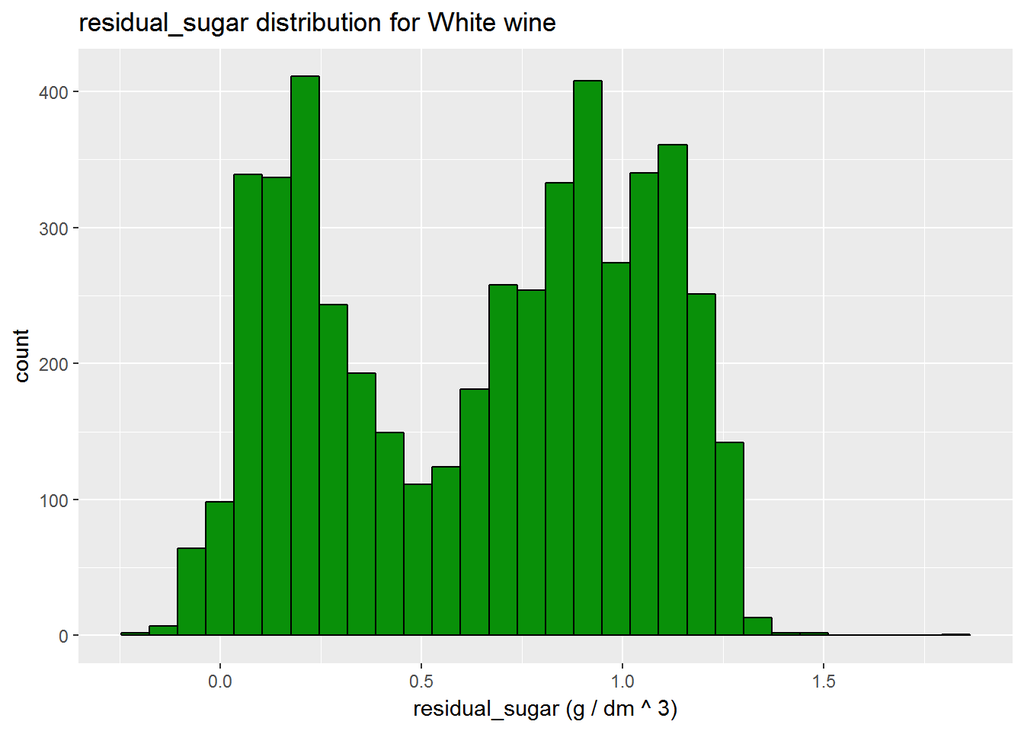

This plot shows a bimodaldistribution which implies that it has two major range for its quantity that are used in our sample. So it can be depicted that our samples are taken from two main regions where concentration of residual sugar was different.

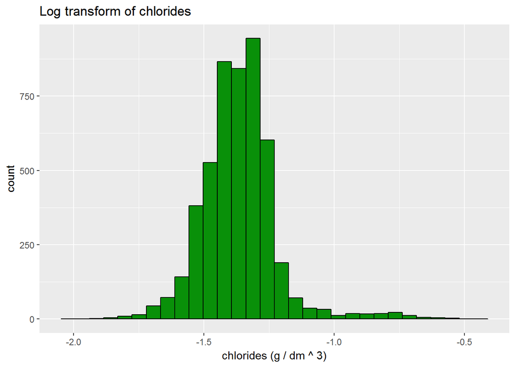

```
##    Min. 1st Qu.  Median    Mean 3rd Qu.    Max.
## 0.00900 0.03600 0.04300 0.04577 0.05000 0.34600
```

chlorides gives the amount of salt in the wine.

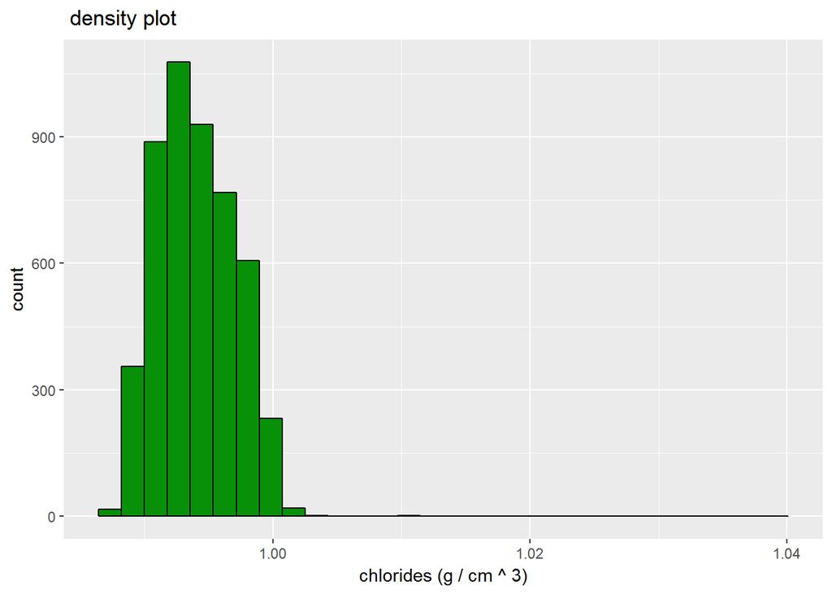

density of wine is close to that of water depending on the percent alcohol and sugar content.The distribution is normal approaching to 1 which is density of water.

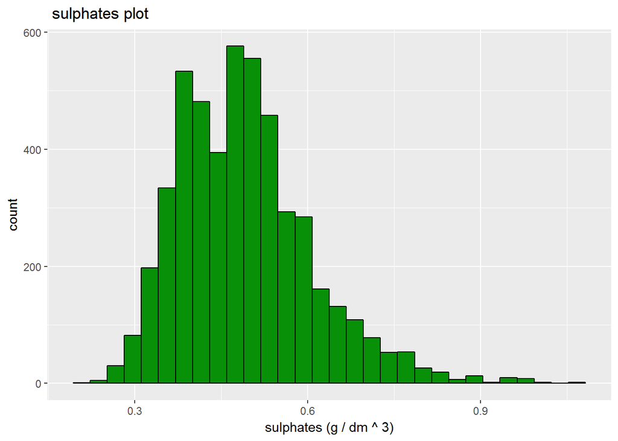

A wine additive which can contribute to sulfur dioxide gas (S02) levels, wich acts as an antimicrobial and antioxidant.As expected from free sulfur dioxide graph this graph is also positive skewed with long tail.

# Bivariate Plots Section

In this section we will find relation between two variables of our dataset and then discuss about the outcomes based on those plots and analysis.

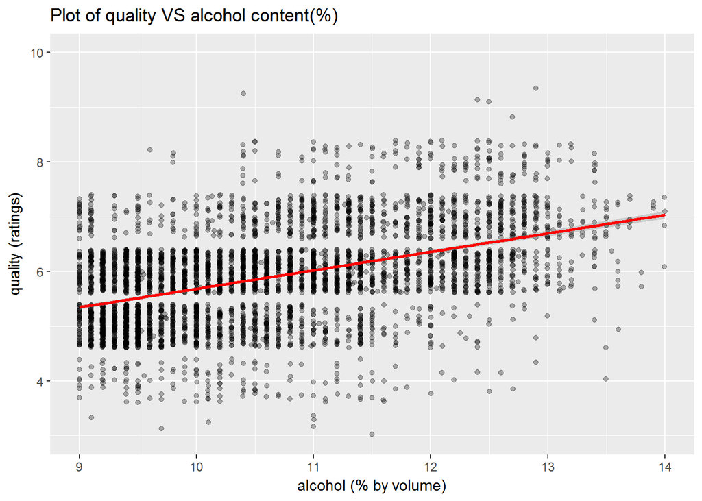

```
## [1] 0.4355747
```

here we see a clear trend of rising quality with alcohol concentration but their are many outliers too like at the right bottom and left top of scatter plot ,I see some dots which are not desirable. Overall correlation between these two variable loos good and is about .435 .

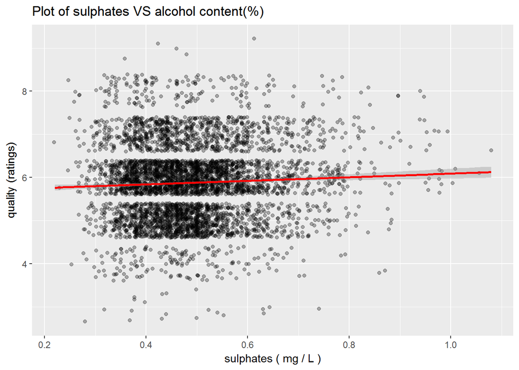

```
## [1] 0.05367788
```

Here we observe a nearly straight line in middle which indicates that both the variables are not much related and correaltion is also as low as .053 .

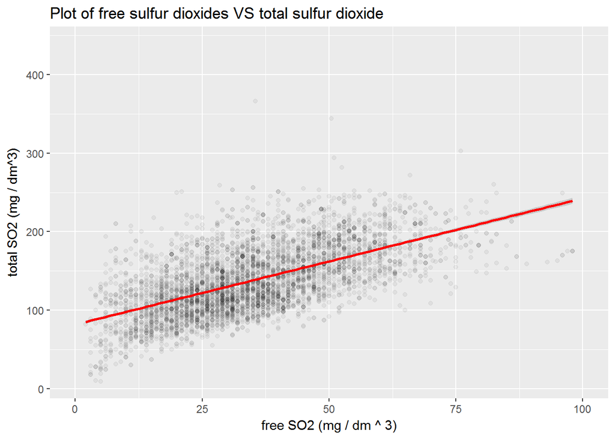

```
## [1] 0.615501
```

Here we see that there is a strong correlation between both of these variables, which is obvious because as the value of free sulphur dioxide will increase then it will surely result in the increase of total sulphur dioxide.

[figure not shown]

# Multivariate Plots Section

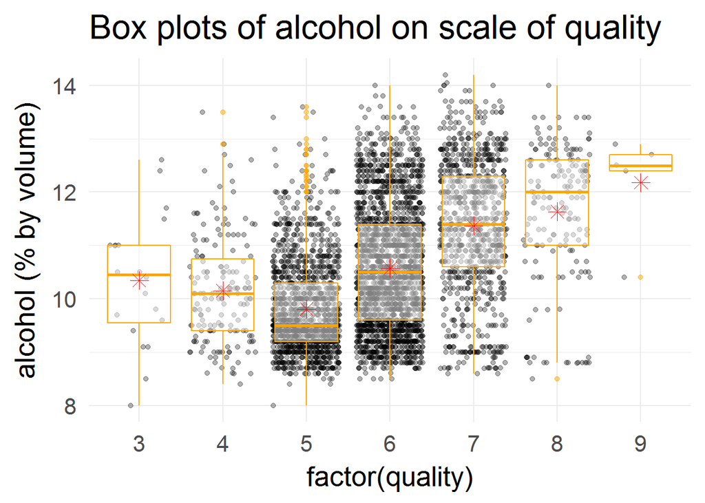

In this Box plot we can see that x-axis have 7 points from 3-9. and for each rating of quality box plot is plotted with mean value as reference. It is observed that most of the sample is at rating 5 & 6.

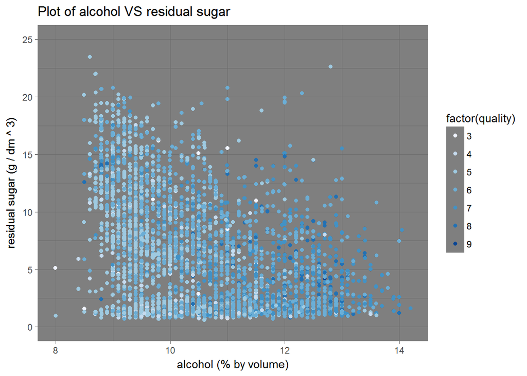

In this plot our qualitative variable is quality and we can see in the plot that there upper value of y is 25 because i have limited the plot on y-axis to remove outliers present so that we can see a better relationship between residual sugar and alcohol concentration.

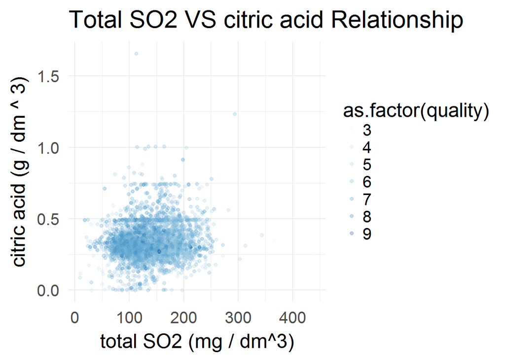

In this plot we can see that when content of total SO2 is between 100-150 and citric acid value is ranging between .25-.5 , then we are getting some good quality of wine.

# Final Plots and Summary

### Plot One

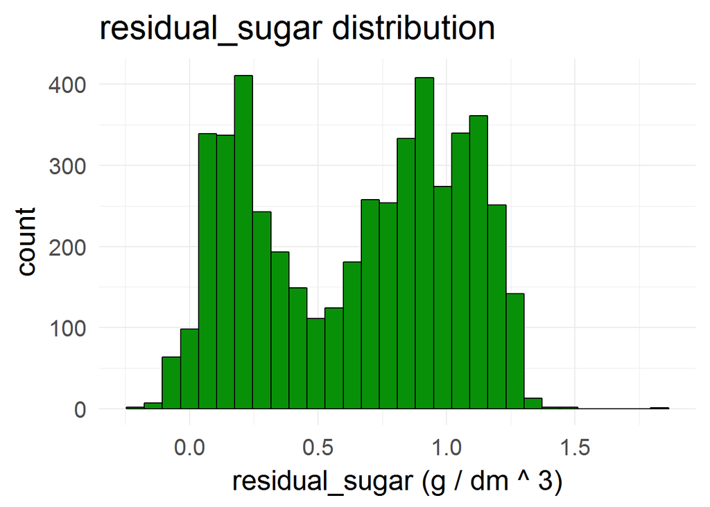

```
##    Min. 1st Qu.  Median    Mean 3rd Qu.    Max.
##   0.600   1.700   5.200   6.391   9.900  65.800
```

### Description One

When we plotted for residual sugar for with normal scale then nothing was clear from the plot and taking this to log scaale we found a bimodal plot. It is rare to find wines with a level of less than 1 g/L. and we have minimum value of 0.6 so some wines are below desired level and we see that maximun value if at 65.80 which is an outlier

### Plot Two

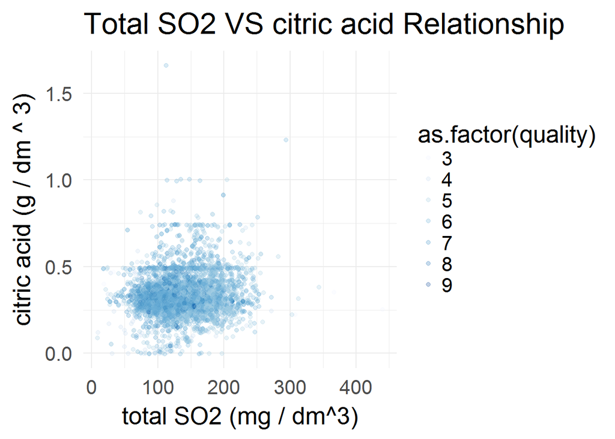

### Description Two

Sulfur dioxide plays two important roles. Firstly, it is an anti-microbial agent, and as such is used to help curtail the growth of undesirable fault producing yeasts and bacteria. Secondly, it acts as an antioxidant, safeguarding the wine’s fruit integrity and protecting it against browning. Whereas citric acid determines the freshness. So these two parameter plays an important role in determining the quality of wine and that we have analysed in this plot.

### Plot Three

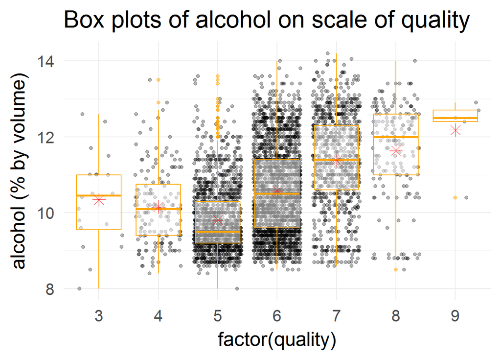

### Description Three

Box plots characterize a sample using the 25th, 50th and 75th percentiles-also known as the lower quartile (Q1), median (m or Q2) and upper quartile (Q3)-and the interquartile range (IQR = Q3 - Q1), which covers the central 50% of the data. So this plots gives the summary of alcohol content with mean value for each rating of quality.

# Reflection